# Replication of working paper:What Can Historically Black Colleges and Universities Teach about Improving Higher Education Outcomes for Black Students?

Authors

Name: Manvanth Sunadreshan

Email: Sudareshan.manvanth@stud.hs-fresenius.de

Matriulation number: 400353080

Published

February 2, 2025

# 1 Abstract

# 2 Introduction

Replicating a study in R usually involves a workflow of loading, cleaning and analyzing data sets in an attempt confirm the findings of a study. For instance, in Price & Viceisza (2023), their replication package is exclusively geared towards generating three foundation tables using publicly available data sources such as the National Center for Education Statistics (NCES), Gallup and the MSI Data Project.

We start with the function importing the data into R (read. csv() or read_excel(), and then manipulated the data with dplyr or tidyverse packages, filtering and transforming variables of interest. Calculating summary statistics and making comparison between HBCUs and other colleges is done with functions.such as summary(), group_by(), and mutate().

These workflows are scripted and show each step taken in the analysis pipeline to ensure it can be reproduced. For export of results into formatted tables xtable() (LaTeX) or kable() (Markdown) are used. The data and code are publicly available in the replication package for transparency.

# 3 Objective

The primary aim behind replication in R is to reproduce and validate the findings presented by Price & Viceisza (2023) concerning the effects of Historically Black Colleges and Universities (HBCUs) on the higher education achievements of black scholars. Conveniently, based on this replication using other existing, publicly available data sets by prior research studies (NCES, Gallup and the MSI Data Project), we are able to ensure the accuracy and validity of this study’s findings. This is dangerously useful to the research in both economic and social sciences as it will increase transparency, credibility and reproducibility, hence allows other researchers to add to the body of knowledge delivering outcomes which other can validate.

This is mainly aimed at creating systematic processing and analyzing the data sets that yield statistical values similar to those in the release study. Such process requires data cleansing, transformation and statistical computations with R programming language to emulate the three major tables delivered in the study. Finally, by scripting the steps taken for the analysis in R, the second goal of the replication is to showcase best practices of empirical research, which help in providing both reliable and reproducible data manipulation and statistical tests.

Moreover, the replication process helps advocate for institutions like HBCUs that improve student success across metrics like graduation rates and economic mobility. The replication validates the robustness of the study’s findings, which helps ensure that policy discussions and educational reforms based on their results are founded on reliable empirical evidence. The method also provides a roadmap to other researchers who might be interested in attempting similar replication work, emphasizing the importance of data integrity and replicability in social science research.

# 4 Methodology

To validate the results of Price & Viceisza (2023), we follow a strict methodology and use R to replicate the process. This approach starts with the collection of the data, which are publicly available data sets from the NCES, the Gallup, and the MSI Data Project that are accessed and downloaded. These data sets include important variables pertaining to the enrollment, graduation and post-graduate outcomes of students at HBCU’s and non-HBCU’s.

Then comes the data cleaning and pre-processing step, where observations we are interested in are filtered, handling missing data, and processing variables to be in line with the origin study. R packages including dplyr and tidyverse are used for this step, as they allow for manipulating and structuring data. They are followed by functions such as summary(), group_by(), and mutate() to generate key descriptive statistics and comparisons. This is followed by data preparation, statistical analyses and replication of tables. Finally, replication output is validated against the results of the original study to check for consistency.

# 5 R

What does R language mean? R is a free software programming language used for statistical computing and graphics supported by the R Foundation for Statistical Computing. Thanks to its versatility, extensive package ecosystem, and solid visualization capabilities, it is commonly utilized in academia, research, and industry. Created by Ross Ihaka and Robert Gentleman in the early 1990s, R has established itself as a go-to tool for data scientists, economists, and statisticians.

So, why R? Do you know that R has a complete package system? And, thanks to popular R packages (e.g., the tidyverse (dplyr, ggplot2, tidyr) isolates, efficient data manipulation and visualization; lm(), glm() fit additional statistical models. Statistical methods like regression, autism, t-tests, etc., can be moted easily in R, Therefore R is also useful in seamless machine learning, time series analysis, econometrics through specialized libraries like caret, forecast, plm, etc.

Therefore, R is a very popular tool in replication studies, data science, and research in general, thanks to its ability to produce reproducible pipelines and dynamic reporting via R Markdown and Shiny applications. It seamlessly works with other tools such as Python, SQL and Tableau to make it a versatile solution for modern-day data analytics. R is now one of the most important language used for statistical analysis and reproducible research with a large user community in an active development of new methods.

# 6 R Markdown

R Markdown — An integrated, inter-active document system that can mix code (R), results (tables, plot, numbers…) and text (Markdown syntax) in one document. It supports a number of output formats (HTML, PDF, Word) and perhaps is primarily used for reproducible research, reports, and presentations. Users can create documents that stimuli narrative with R code chunks that they fill in R Markdown. This is commonly used in research and academic fields to ensure transparency and replicability in data-driven studies.

R Quarto — the successor to R Markdown — comes with better flexibility and formatting, as well as improved table rendering capabilities. However, unlike R Markdown, Quarto likes whatever language you wish, maybe Python, Julia, Observable JS, besides R, not excluding better table rendering. If your project requires robust support for tables (e.g. replication studies, economic research), Quarto has better table formatting capabilities than R Markdown.

# 7 **Data Collection**

## 7.1 **Data Collection for Each Table**

The replication process in **R** relies on publicly available datasets to generate the key tables from Price and Viceisza (2023). The data sources for each table are as follows:

### 7.1.1 **Table 1: Characteristics of Selected HBCUs**

- **Data Source**: MSI Data Project (available at : https://www.aeaweb.org/articles?id=10.1257/jep.37.3.213)

The data were filtered for institutions classified as “Historically Black Colleges and Universities (HBCU’s)” using the **i_hbcuipeds** variable. The data set was further refined by selecting only four-year institutions and sorting them based on **enrollment size** to include the largest HBCUs.

By following the replication process instructions provided in Readme file, table 1 is replicated as shown in Section 8 .

### 7.1.2 **Table 2: Educational and Labor Market Outcomes**

Specific survey years (1993/2003 and 2008/2018 cohorts) were selected to analyze long-term educational and labor market outcomes. Filters were applied to focus on Black students, distinguishing between those who attended HBCU’s and non-HBCU’s.

### 7.1.3 **Table 3: Student Support and Experiential Learning Opportunities**

- **Data Source**: “Gallup-USA Funds Minority College Graduates Report” (available at : https://www.gallup.com/services/186359/gallup-usa-funds-minority-college-graduates-report-pdf.aspx).

The survey was conducted among Black college graduates, comparing those from **HBCU’s vs. non-HBCU’s” on key support metrics. Variables such as faculty mentorship, applied learning experiences, and extracurricular involvement were included in the analysis.

# 8 Replication process of table 1

The process is initiated after acquiring the necessary data, as mentioned in Section 7 (data collection), required to replicate the table titled “2021 Characteristics for Selected Four-Year Historically Black Colleges and Universities”(Figure 3).

The Readme file provides information about, as mentioned in Section 7 (data collection), the file required for replication of table 1(Figure 3) is ” MSI Data Project 03132023.xlsx ” which can be downloaded from the following link: https://nyu.app.box.com/s/kf6ihe5wcm8gc4pkgcbvv5dfzjy2w6rm

After downloading the file by following the instructions provided in the Readme file. The data set for table 1 is obtained(Figure 1).

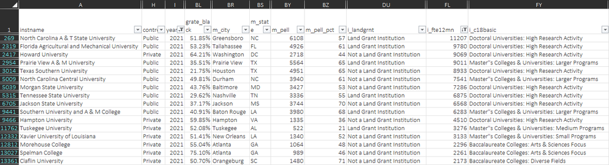

Figure 1: Table 1 Dataset from the “MSI Data Project”

Downloading the replication package is required to access and analysis the various datasets used for replication process. The replication pakacge for this paper is available in the following link: https://www.aeaweb.org/articles?id=10.1257/jep.37.3.213

The replication package also provides this table(Figure 2) that present in the excel file “Price_Viceisza_JEP_Mar2023.xlsx”.

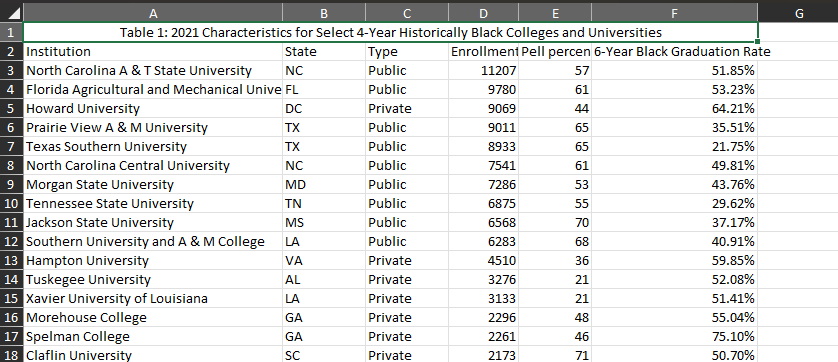

Figure 2: Table 1 Dataset from the Replication package of the working paper

The Figure 3 is available in the working paper. the working paper can be downloaded using the following link: https://www.aeaweb.org/articles?id=10.1257/jep.37.3.213

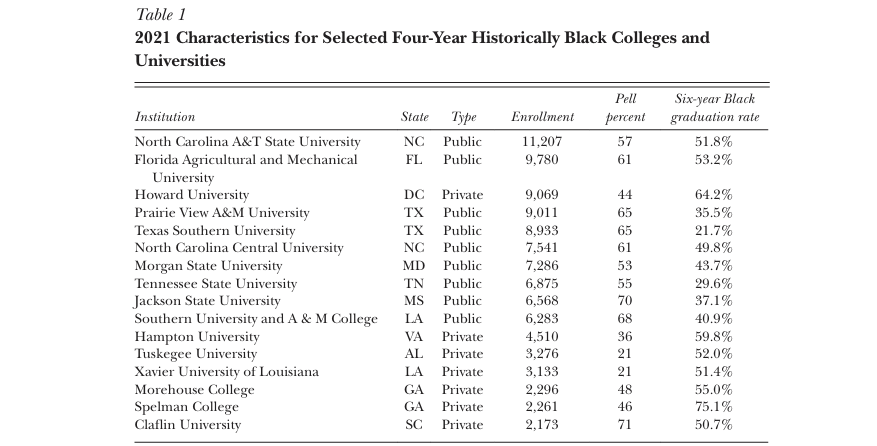

Figure 3: 2021 Characteristics for Selected Four-Year Historically Black Colleges and Universities (Price & Viceisza, 2023)

## 8.1 Loading the necessary libraries

The R code starts with clearing the environment and loading the necessary libraries.

```
rm(list = ls()) # clear Environment

# Define required packages
required_packages <- c("tidyverse", "haven", "dplyr", "readxl", "writexl","knitr")

# Install and load required packages
install_if_missing <- function(pkg) {
  if (!require(pkg, character.only = TRUE)) {
    install.packages(pkg, dependencies = TRUE)
    library(pkg, character.only = TRUE)
  }
}
# Apply function to each package
lapply(required_packages, install_if_missing)
```

## 8.2 Read in the data

Read in the data set using read.excel() function which is used for replication. Using view() to view the data set.

CODE:

```
table_1_data <- read_excel("D:/Hochschule Fresenius notes (sem2)/SS 2024- Data,
Science in business/Final_Project_2/P2_WD/MSI Data Project - July 2023 -
V1.1.xlsx",sheet = "Data")
view(table_1_data)
```

## 8.3 Code for replication of table 1

The Readme file clearly provides the necessary step to replicate table 1. By following the steps the table 1 can be generated. By using kable() we can generate the table in quadro html file.

CODE:

```
# Filter for HBCU's (Column DN = 'i_hbcuipeds')
HBCU_i_hbcuipeds_filtered <- table_1_data |>
  filter(i_hbcuipeds == "Yes")
view(HBCU_i_hbcuipeds_filtered)

# Filter to keep only Year 2021 (Column I = 'year')
HBCU_year_filtered <- HBCU_i_hbcuipeds_filtered |>
  filter(year == 2021)
view(HBCU_year_filtered)

# Selecting the colomns required for replication process
HBCU_i_fte12mn_filtered <- HBCU_year_filtered |>
  select(instname, control, year, i_fte12mn, m_state, m_pell_pct,grate_black)
view(HBCU_i_fte12mn_filtered)

# Select the 11 largest institutions based on enrollment (Column FL = 'i_fte12mn')
HBCU_des_filtered <- HBCU_i_fte12mn_filtered |>
  mutate(i_fte12mn = as.numeric(i_fte12mn))|>
  arrange(desc(i_fte12mn))|>
  slice_head(n = 11)
view(HBCU_des_filtered)

# Exclude St. Philip’s College (which has i_fte12mn == 6429)
HBCU_exclude_filtered <- HBCU_des_filtered |>
  filter(i_fte12mn != 6429)
view(HBCU_exclude_filtered)

# Include additional specific institutions based on enrollment values
HBCU_add_filtered <- table_1_data |>
  filter(i_hbcuipeds == "Yes") |>
  filter(year == 2021) |>
  select(instname, control, year, i_fte12mn, m_state, m_pell_pct,grate_black) |>
  filter(i_fte12mn %in% c(4510, 3276, 3133, 2296, 2261, 2173)) |>
  mutate(i_fte12mn = as.numeric(i_fte12mn))
view(HBCU_add_filtered)

# Combine both data sets
combo_HBCU_table <- bind_rows(HBCU_exclude_filtered, HBCU_add_filtered)
view(combo_HBCU_table)

# Convert grate_black into percentage from numeric
final_HBCU_table <- combo_HBCU_table  |>
  mutate(grate_black = as.numeric(grate_black)) |>
  mutate(grate_black = paste0(grate_black * 100,"%"))
view(final_HBCU_table)

# Rename columns to generate the table 1
HBCU_table_1 <- final_HBCU_table |>
  rename(
    Institution = instname,
    State = m_state,
    Type = control,
    Enrollment = i_fte12mn,
    `Pell Percent` = m_pell_pct,
    `6-Year Black Graduation Rate` = grate_black
  )
view(HBCU_table_1)
```

TABLE 1 : 2021 Characteristics for Selected Four-Year Historically Black Colleges and Universities

[output not shown]

# 9 Replication process of table 2

The replication of table 2 demands the datasets “PowerStats_AveragesMediansPercents_2003” and “PowerStats_AveragesMediansPercents_2018” from “Baccalaureate and Beyond” which can be accessed through the link: https://nces.ed.gov/surveys/b&b/index.asp

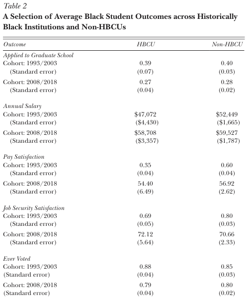

Figure 4: A Selection of Average Black Student Outcomes across Historically Black Institutions and Non-HBCUs(Price & Viceisza, 2023)

The Readme file provides the step-by-step process to get both the datasets. Both the datasets are given in the Figure 5 and Figure 7 and replication pakage provides the two dataset that are shown in Figure 6 and Figure 8 With careful observation we can come to a conclusion that the values match. Therefore, the datasets (Figure 5 and Figure 7) can be used for replication process.

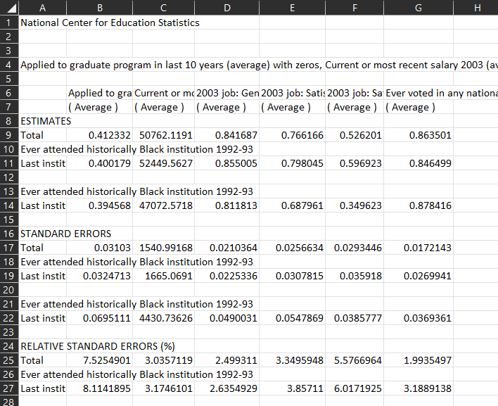

Figure 5: Table 2 Dataset from the “AverageMediansPercents_2003”

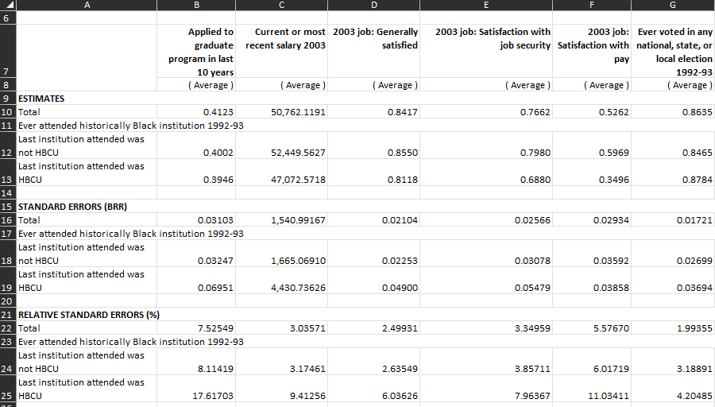

Figure 6: Table 2 Dataset “AverageMediansPercents_2003” from replication package

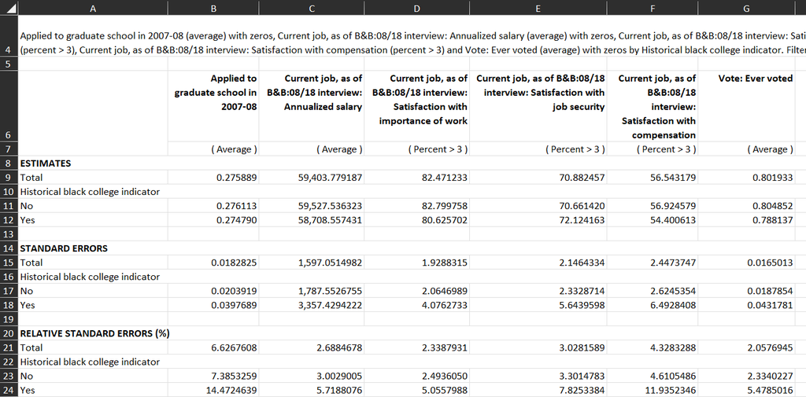

Figure 7: Table 2 Dataset from the “AverageMediansPercents_2018”

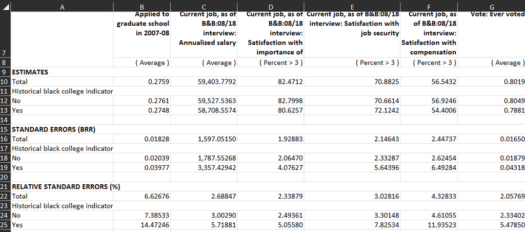

Figure 8: Table 2 Dataset “AverageMediansPercents_2018” from replication package

## 9.1 Code for replication of table 2

The Readme file provides the necessary step to download the dataset replicating table 2. By following the datasets for the table 2 can be generated.The steps to replication have not been mentioned, using the aquired knowledge of data processing and manipulation techiniques the table can be replicated.

The challaneges faced during replication process is dicussed in Section 11. By using kable() we can generate the table in quadro html file.

CODE:

```
table_2_2003_data <- read_excel("D:/Hochschule Fresenius notes (sem2)/SS 2024- .
Data Science in business/Final_Project_2/P2_WD/PowerStats_AveragesMediansPercents,
_2003.xlsx") #read in the data
table_2_2018_data <- read_excel("D:/Hochschule Fresenius notes (sem2)/SS 2024- ,
Data Science in business/Final_Project_2/P2_WD/PowerStats_AveragesMediansPercents,
_2018.xlsx") #read in the data

# Data pre-processing

#table_2003
table_2003_cleaned_data <- table_2_2003_data  |>
  slice(5:21) |>
  select(1:7) |>
  filter(if_any(everything(), ~ !is.na(.))) |>
  slice(c(6, 8, 12, 14))

#table_2018
table_2018_cleaned_data <- table_2_2018_data  |>
  slice(5:17) |>
  select(1:7) |>
  filter(if_any(everything(), ~ !is.na(.))) |>
  slice(c(6, 7, 11, 12))

# Standardize column names to prevent mismatches
colnames(,table_2003_cleaned_data) <- paste0("Col_", seq_along
(colnames(table_2003_cleaned_data)))
colnames(table_2018_cleaned_data) <- paste0("Col_",seq_along(colnames(
table_2018_cleaned_data)))
combo_HBCU_table_2 <- bind_rows(table_2003_cleaned_data, table_2018_cleaned_data)

# Applied to Graduate School
HBCU_table_2_arrange <- combo_HBCU_table_2 |>
  select(Col_2)

HBCU_1 <- HBCU_table_2_arrange[-c(1, 3, 5, 7), ]
NON_HBCU_1<- HBCU_table_2_arrange[-c(2, 4, 6, 8), ]
Applied_to_Graduate_School <- bind_cols(HBCU_1, NON_HBCU_1) |>
  setNames(c("HBCU", "NON-HBCU"))

# Annual Salary
```

[output cut: 47 more lines]

```
  mutate(Outcome = c(" Cohort: 1993/2003","(Standard error)"," Cohort: 2008/2018","(Standard error)"," Cohort: 1993/2003","(Standard error)"," Cohort: 2008/2018","(Standard error)"," Cohort: 1993/2003","(Standard error)"," Cohort: 2008/2018","(Standard error)"," Cohort: 1993/2003","(Standard error)"…
  select(Outcome, everything())

HBCU_table_2 <- add_row(HBCU_table_2,
                                   Outcome = "Applied to Graduate School", .before = 1)
HBCU_table_2 <- add_row(HBCU_table_2,
                                   Outcome = "Annual Salary", .before = 6)
HBCU_table_2 <- add_row(HBCU_table_2,
                                   Outcome = "Pay Satisfaction", .before = 11)
HBCU_table_2 <- add_row(HBCU_table_2,
                                   Outcome = "Job Security Satisfaction", .before = 16)
HBCU_table_2 <- add_row(HBCU_table_2,
                                   Outcome = "Ever Voted", .before = 21)

view(HBCU_table_2)
```

Table 2 : A Selection of Average Black Student Outcomes across Historically Black Institutions and Non-HBCUs

| Outcome | HBCU | NON-HBCU |
| --- | --- | --- |
| Applied to Graduate School | NA | NA |
| Cohort: 1993/2003 | 0.39456799999999997 | 0.40017900000000001 |
| (Standard error) | 6.9511100000000006E-2 | 3.2471300000000002E-2 |
| Cohort: 2008/2018 | 0.27479 | 0.276113 |
| (Standard error) | 0.0397689 | 0.0203919 |
| Annual Salary | NA | NA |
| Cohort: 1993/2003 | 47072.571790000002 | 52449.562700000002 |
| (Standard error) | 4430.7362599999997 | 1665.0690950000001 |
| Cohort: 2008/2018 | 58708.557431 | 59527.536323 |
| (Standard error) | 3357.4294222 | 1787.5526755 |
| Pay Satisfaction | NA | NA |
| Cohort: 1993/2003 | 0.34962300000000002 | 0.59692299999999998 |
| (Standard error) | 3.8577699999999999E-2 | 3.5917999999999999E-2 |
| Cohort: 2008/2018 | 54.400613 | 56.924579 |
| (Standard error) | 6.4928408 | 2.6245354 |
| Job Security Satisfaction | NA | NA |
| Cohort: 1993/2003 | 0.68796100000000004 | 0.798045 |
| (Standard error) | 5.4786899999999999E-2 | 3.07815E-2 |
| Cohort: 2008/2018 | 72.124163 | 70.66142 |
| (Standard error) | 5.6439598 | 2.3328714 |
| Ever Voted | NA | NA |
| Cohort: 1993/2003 | 0.87841599999999997 | 0.846499 |
| (Standard error) | 3.6936099999999999E-2 | 2.69941E-2 |
| Cohort: 2008/2018 | 0.788137 | 0.804852 |
| (Standard error) | 0.0431781 | 0.0187854 |

After going through hours of data manipulation and iterations, table 2 have been successfully replicated.

# 10 Replication process of table 3

The Readme file specifies that the dataset(Figure 10) is directly adopted from the report paper of Gallup(2015).However,the source of the report is provide which can be downloaded from the following link: https://www.gallup.com/services/186359/gallup-usa-funds-minority-college-graduates-report-pdf.aspx

There is not data set available for replication of table 3. However, the replication package provides us with a sheet in “Price_Viceisza_JEP_Mar2023.xlsx” that can be used to replicate the table.

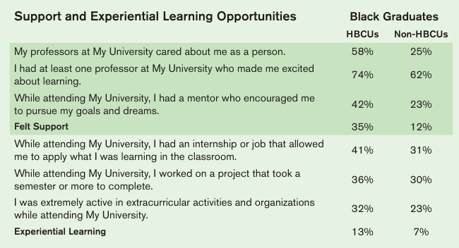

Figure 9: Table on page 18 of Gallup (2015)

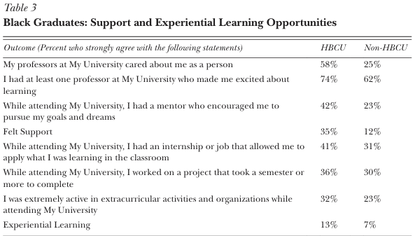

Figure 10: Black Graduates: Support and Experiential Learning Opportunities(Price & Viceisza, 2023)

## 10.1 Code for replication of table 3

https://www.gallup.com/services/186359/gallup-usa-funds-minority-college-graduates-report-pdf.aspx

```
# Generating table 3
# Read in the data

table_3_data <- read_excel("D:/Hochschule Fresenius notes (sem2)/SS 2024-,
Data Science in business/Final_Project_2/P2_WD/Price_Viceisza_JEP_Mar2023.xlsx",
sheet = "Table 3 (Gallup Report Page 18)")
# Set first row as column names
colnames(table_3_data) <- as.character(table_3_data[1, ])
table_3_data <- table_3_data[-1, ]# Remove the first row
view(table_3_data)
```

Table 3 : Black Graduates: Support and Experiential Learning Opportunities

| Outcome (Percent who strongly agree with the following statements) | HBCU | Non-HBCU |
| --- | --- | --- |
| My professors at My University cared about me as a person | 0.57999999999999996 | 0.25 |
| I had at least one professor at My University who made me excited about learning | 0.74 | 0.62 |
| While attending My University, I had a mentor who encouraged me to pursue my goals and dreams | 0.42 | 0.23 |
| Felt Support | 0.35 | 0.12 |
| While attending My University, I had an internship or job that allowed me to apply what I was learning in the classroom | 0.41 | 0.31 |
| While attending My University, I worked on a project that took a semester or more to complete | 0.36 | 0.3 |
| I was extremely active in extracurricular activities and organizations while attending My University | 0.32 | 0.23 |
| Experiential Learning | 0.13 | 7.0000000000000007E-2 |

By using this code the replication of table 3 can be done sucessfully and obtain the table as shown in Figure 10 .

# 11 Challenges faced during replication

## 11.1 Challenges in replicating table 1

- In Readme file ‘i_hbcipeds’ is given as column DM but it is under column DN.
- In Readme file ‘i_fete12mn’ is given as column FK but it is under Column FL.
- Columns m_city,i_landgrnt,i_c18basic is not required for the replication process of table 1 as per Readme file.
- ‘i_fete12mn’ has character values that need to be converted to numeric values.
- The output of the table 1 in pdf is displayed beyond the margins. A proper solution could not be found to solve this issue. It is however visible in the standalone. html fime uploaded in the repository.

## 11.2 Challenges in replicating table 2

- Incomplete instructions when it comes to filter application in website that is required to attain the required data set values in Readme file (percentage information missing). Was later observed in the data set provided in the replication package, which assisted in acquiring proper data set values.
- No instructions provided for the replication process of table 2. Readme file only provides information on acquiring the required data set.
- Data set’s complexity made data-processing time consuming.
- Unable to remove Na values in output table. which can be seen in replicated output of table 2 in Section 9.1

## 11.3 Challenges in replicating table 3

- No data set available in csv/ xlsx format but the replication package contains table 3 in ‘.xlsx’ format.
- Cannot reference Gallup report as it’s bibtex file was not found.
- The output of the table 3 in pdf is displayed beyond the margins. A proper solution could not be found to solve this issue. It is however visible in the standalone. html fime uploaded in the repository.

# 12 Tools used

Th study supporting my replication process is supported by the lecture notes provided by Prof. Dr. Stephan Huber, which can be accessed at [https://hubchev.github.io/ds/] .

# 13 Publishing presentation in Github

They help streamline software development by using Git and GitHub by offering strong collaboration, code reviews, and project management. These tools allow developers to collaborate seamlessly and streamline version control, helping to keep projects structured and easy to find. Furthermore, GitHub is a great website for people who are trying to become programmers because it encourages collaboration and knowledge sharing. More detailed instructions can be found on Professor Dr. Stephan Huber’s GitHub account (hubchev/ds_summer23)

To control and display the project at once, we made a repository called “data_science_project.github.io”, in which you can upload standalone HTML files and other documents of interest. After the application of changes in the GitHub repo and reviewed the updates, I am using my official username on GitHub so named my repository in the format of project-repository name, followed by the stored website as an HTML format. The last step is pushing all relevant project files to the repository, ensuring that they are easily accessible.

Repository link : https://github.com/codeflex98/data_science_project.github.io

## 13.1 Future scope

Future Scope

Replicating the findings of Price & Viceisza (2023) using R opens several avenues for future research opportunities and methodological advances. A significant opportunity for growth is the inclusion of more data sets, such as longitudinal labor market surveys or administrative education data, to strengthen our comparative studies between HBCU’s and non-HBCU’s.

Future studies may also use machine learning techniques to identify predictive features of graduation rates and economic mobility outcomes among Black students. Moreover, the advancements in R Quarto and other automated reporting tools in the future of replication can be improved with dynamic visualizations, interactive tables and dashboards that would also make research findings more accessible to policymakers and educators.

In addition, the expanded availability of open-access educational data creates an opportunity for multi-institutional comparative studies that assess the greater influence of institutional policy on student success. It may also be possible to expand replication efforts beyond the U.S. context to compare historically underrepresented institutions and target educational policy in other nations to draw valuable global insights regarding the effectiveness of such measures.

# 14 Conclusion

Additionally, this work illustrates the necessity of replication in empirical studies since such efforts are not only critical to confirm previous estimates, but they also create opportunities for progress by analysis over larger samples, machine learning applications, and internationally. Such tools, including R Quarto for dynamic reporting and visualization, help make research more accessible and impactful to policymakers and educators.

# 15 Affidavit

I hereby affirm that this submitted paper was authored unaided and solely by me. Additionally, no other sources than those in the reference list were used. Parts of this paper, including tables and figures, that have been taken either verbatim or analogously from other works have in each case been properly cited with regard to their origin and authorship. This paper either in parts or in its entirety, be it in the same or similar form, has not been submitted to any other examination board and has not been published.

I have read the Handbook of Academic Writing by Hildebrandt & Nelke (2019) and have endeavored to comply with the guidelines and standards set forth therein.

I acknowledge that the university may use plagiarism detection software to check my thesis. I agree to cooperate with any investigation of suspected plagiarism and to provide any additional information or evidence requested by the university.

The report includes:

$$Manvanth Sundareshan$$
$$02.02.2025$$
$$Cologne,Germany$$

## 16 11 References

Price, G. N., & Viceisza, A. C. G. (2023). What can historically black colleges and universities teach about improving higher education outcomes for black students? *Journal of Economic Perspectives*, *37*(3), 213–232. https://doi.org/10.1257/jep.37.3.213